# Exam 1

## Exam 1

#### Question

1. Una vez inicia la migración del atún en una cierta región del país, la pesca varía diariamente según la expresión

   $$P = -2d^2 + 9d + 91$$

   Donde $P$ representa la pesca, en toneladas, y $d$ los días transcurridos después de iniciada la migración.

   ¿Cuál de las siguientes gráficas muestra correctamente la relación entre la pesca y los días transcurridos después de iniciada la migración?

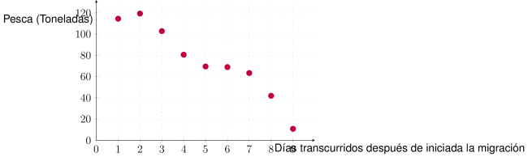

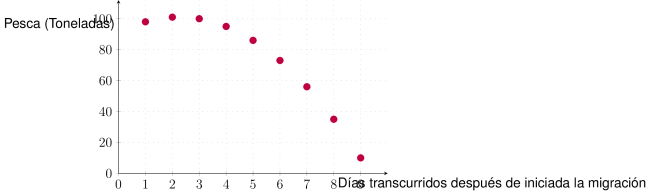

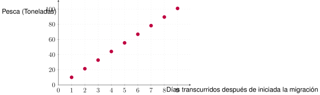

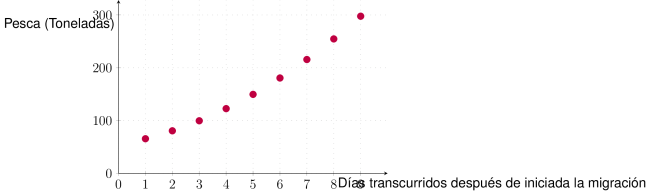

#### Solution

   Para determinar cuál gráfica es correcta, debemos identificar aquella que represente fielmente la función cuadrática dada:

   $$P = -2d^2 + 9d + 91$$

   **Análisis de la función:**

   Esta es una función cuadrática (parábola) donde:
   - El coeficiente de $d^2$ es $-2$ (negativo), lo que indica que la parábola abre hacia abajo
   - El coeficiente de $d$ es $9$
   - El término independiente es $91$

   **Características esperadas del gráfico correcto:**
   1. Los puntos deben formar una parábola que abre hacia abajo (forma de “U” invertida)
   2. La pesca aumenta inicialmente, alcanza un máximo, y luego disminuye
   3. Los valores deben coincidir con la evaluación de la función en diferentes días

   **Verificación:**

   Podemos verificar algunos puntos evaluando la función:
   - Para $d = 1$: $P = -2(1)^2 + 9(1) + 91 = 98$
   - Para $d = 5$: $P = -2(25) + 9(5) + 91 = 86$

   La gráfica correcta es aquella cuyos puntos coinciden con estos valores calculados y muestran el patrón característico de una parábola invertida.

   **Errores en las opciones incorrectas:**

   Las gráficas incorrectas pueden presentar:
   - Patrón lineal (línea recta) en lugar de cuadrática
   - Parábola con orientación incorrecta (abre hacia arriba)
   - Oscilaciones o variaciones que no corresponden a una función cuadrática
   - Valores que no coinciden con la ecuación dada
   1. Incorrecto. Esta gráfica no representa correctamente la función cuadrática especificada.
   2. Correcto. Esta gráfica representa fielmente la función cuadrática $P = -2d^2 + 9d + 91$, mostrando una parábola invertida como se espera.
   3. Incorrecto. Esta gráfica no representa correctamente la función cuadrática especificada.
   4. Incorrecto. Esta gráfica no representa correctamente la función cuadrática especificada.